# Musical Ambiguous Figure Data Analysis

**Author:** Sarah Gates  
**Contact** sarahgates22@gmail.com  
**Date:** Summer, 2022

## Introduction

This R notebook contains the statistical analysis for my Musical Ambiguous Figures project. In the first section, I perform the statistical analyses on the first dependent variable, ease of hearing ratings. I first examine the assumptions for parametric statistical analysis (outliers, normality), then perform a mixed factorical ANOVA to examine the effects of three within-subject factors (sonata section, attended feature and modulation type) and one between subject factor (expertise group) on ease of hearing ratings. Secondly, I perform the same analysis on the second dependent variable, ease of change rating, examining the effects of two within-subject factors (sonata section, attended feature) and one between-subjects factor (expertise) on this DV.

### Hypotheses

Here are the hypotheses restated:

**H0:** This excerpt is not amenable to multiple interpretations, using either scale degrees or Galant schemata.

**H1a:** This excerpt is amenable to multiple interpretations in terms of schemata; however, one interpretation (Prinner) may be easier to hear than the other (Romanesca). **H1b:** Furthermore, the availability of and ease of change between interpretations may differ between the expositional and recapitulatory versions of the excerpt (with the Romanesca more available in the recapitulation).

**H2:** Participants should be able to more easily form and alternate between scale degree interpretations for a single voice (soprano, bass) than for Galant schemata (which are dependent on the presence of multiple, co-occurring features).

**H3:** The ability to form and alternate Galant schemata interpretations may be dependent on moderate familiarity, but not a high-level expertise with Galant schemata (Expertise categories = Novice, Intermediate, Expert). Expertise should therefore be related to increased rigidity of interpretation (Ease of Change on a scale from 1 to 7, low to high), particularly for Schema interpretations, as such categories are overlearned and more likely to be automatically active during listening.

### Data Dictionary

`Random_IDs:` randomly generated integer, unique identifier for each participant  
`Sonata_Section:` the section of the sonata form from which the stimuli was taken for that trial (or row, is either exposition or recapitulation)  
`Feature:` the feature (soprano scale degree line, bass scale degree line, or schema) that the participant attended to in that trial (or row)  
`Mod_Type:` the modulation type indicated by the schema (Prinner: modulating, Romanesca: non-modulating) for the trial  
`Education_Level:` the education level of the participant (graduate student, post-doc, professor, other)  
`Year_Theory:` the years of music theory training and/or teaching for each participant  
`Years_Skills:` the years of aural skills training and/or teaching for each participant  
`Schemata_Expertise:` self-reported expertise in Galant schemata theory (completely unfamiliar, somewhat familiar, familiar, very familiar, I am an expert)  
`Excerpt_Familiarity:` self-reported familiarity with the sonata (Mozart, K 280) (First time hearing this, hear before, very familiary)  
`Excerpt_Analysis:` indicates whether the participant has performed score analysis of the sonata (no not at all, yes somewhat, yes extensively)  
`Solfege_Hearing:` integer from 1-7 indicating the participants’ ability to hear scale degrees while listening (1: cannot hear, 7: can easily hear)  
`Schema_Hearing:` integer from 1-7 indicating the participants’ ability to hear Galant schemata while listening (1: cannot hear, 7: can easily hear)  
`Perfect_Pitch:` whether the participant has perfect pitch or not (yes/no)  
`Interpretation_App:` string of options selected by the participant about how they formed interpretations of the excerpt (e.g., imagery, subvocalization, etc.)  
`Expertise_Group:` constructed variable (see data cleaning notebook) indicating the participants’ Galant schema expertise level (novice, intermediate, expert)  
`Expertise_Group_solf:` constructed variable (see data cleaning notebook) indicating the participants’ solfege expertise level (novice, intermediate, expert)  
`Order Variables:` variables indicating the order of presentation for each level of stimuli presentation (e.g., Sonata Order = 1 means that the stimuli was presented in the order ‘exposition’ then ‘recapitulation’)

**Targets**

`DV:` ease of hearing rating on a scale from 1-7  
`DV2:` ease of change rating on a scale from 1-7

First, I will load the required packages:

```r
library(ggplot2)
library(tidyverse)
library(ggpubr)
library(rstatix)
```

# Statistical Analysis: Dependent Variable 1 (Ease of Hearing Ratings)

In this section, I perform the analyses on the first dependent variable.

```r
# loading the data
df <- readfile <- read.csv("data/amb_DV1_fin.csv")

# view the data
View(df)

# Examine the data contents and data types
str(df)
```

```
'data.frame':   228 obs. of  27 variables:
 $ X                   : int  0 1 2 3 4 6 7 8 9 10 ...
 $ Random_IDs          : int  913 834 719 862 686 998 473 895 326 381 ...
 $ Sonata_Section      : chr  "Exposition" "Exposition" "Exposition" "Exposition" ...
 $ Feature             : chr  "Bass" "Bass" "Bass" "Bass" ...
 $ Mod_Type            : chr  "Romanesca" "Romanesca" "Romanesca" "Romanesca" ...
 $ DV                  : num  7 5.1 6.5 4.6 7 5 5.2 1 6.5 1 ...
 $ Education_Level     : chr  "Professor" "Graduate Student" "Graduate Student" "Graduate Student" ...
 $ Years_Theory        : chr  "10 + years" "5-10 years" "1-2 years" "5-10 years" ...
 $ Years_Skills        : chr  "10 + years" "5-10 years" "3-5 years" "5-10 years" ...
 $ Schemata_Expertise  : chr  "Completely unfamiliar" "Familiar" "Somewhat familiar" "Very familiar" ...
 $ Excerpt_Familiarity : chr  "I have heard this before" "This was the first time I have heard this" "I have heard this before" "This was the first time I have heard this" ...
 $ Excerpt_Analysis    : chr  "No, not at all" "No, not at all" "No, not at all" "No, not at all" ...
 $ Solfege_Hearing     : num  7 6.2 5.3 5.5 7 4 6 4 6.1 7 ...
 $ Schema_Hearing      : num  1 5.7 4.5 4.9 7 2 5.1 1 4 1 ...
 $ Perfect_Pitch.      : chr  "No" "No" "No" "No" ...
 $ Interpretation_App  : chr  "I have no idea, I could just hear it!,I imagined scale degrees or solfege as I listened,I imagined or sung/spok"| __truncated__ "I imagined scale degrees or solfege as I listened" "I imagined scale degrees or solfege as I listened,I sang or spoke (without scale degrees…
 $ Expertise_Group     : chr  "Novice" "Intermediate" "Intermediate" "Intermediate" ...
 $ Expertise_Group_solf: chr  "Expert" "Intermediate" "Intermediate" "Intermediate" ...
 $ Sonata_Order        : int  2 1 2 1 2 1 2 2 2 1 ...
 $ Expo_Order          : int  5 3 3 3 1 6 5 6 1 5 ...
 $ Expo_Bass_Order     : int  1 2 2 1 2 1 1 2 1 1 ...
 $ Expo_Sop_Order      : int  1 2 2 1 1 2 1 1 1 2 ...
 $ Expo_Schema_Order   : int  2 2 1 1 1 2 1 1 1 2 ...
 $ Recap_Order         : int  3 1 6 3 4 3 3 2 3 6 ...
 $ Recap_Bass_Order    : int  1 2 2 1 1 1 2 2 2 1 ...
 $ Recap_Sop_Order     : int  1 2 1 2 1 1 1 2 1 1 ...
 $ Recap_Schema_Order  : int  2 1 1 2 1 1 2 2 1 2 ...
```

## 1. Cursory Exploratory Data Analysis

Here, I examine the assumptions before performing statistical analysis, including examining outliers, normality and variance.

```r
# grouping by the different IVs
df %>%
  group_by(Sonata_Section, Feature, Mod_Type, Expertise_Group) %>%
  get_summary_stats(DV, type = "mean_sd")
```

| Sonata_Section | Feature | Mod_Type | Expertise_Group | variable | n | mean | sd |
| --- | --- | --- | --- | --- | --- | --- | --- |
| Exposition | Bass | Prinner | Expert | DV | 5 | 6.820 | 0.402 |
| Exposition | Bass | Prinner | Intermediate | DV | 10 | 5.030 | 1.742 |
| Exposition | Bass | Prinner | Novice | DV | 4 | 5.225 | 2.098 |
| Exposition | Bass | Romanesca | Expert | DV | 5 | 4.760 | 1.785 |
| Exposition | Bass | Romanesca | Intermediate | DV | 10 | 5.830 | 0.973 |
| Exposition | Bass | Romanesca | Novice | DV | 4 | 3.500 | 3.000 |
| Exposition | Schema | Prinner | Expert | DV | 5 | 7.000 | 0.000 |
| Exposition | Schema | Prinner | Intermediate | DV | 10 | 5.660 | 1.825 |
| Exposition | Schema | Prinner | Novice | DV | 4 | 3.975 | 2.210 |
| Exposition | Schema | Romanesca | Expert | DV | 5 | 2.700 | 1.591 |

[output cut: 26 more lines]

Here I visualize the DV along each level of the within-subject factors (sonata section, feaure, modulation type). This shows that there are some outliers for the prinner modulation type in the schema attending condition.

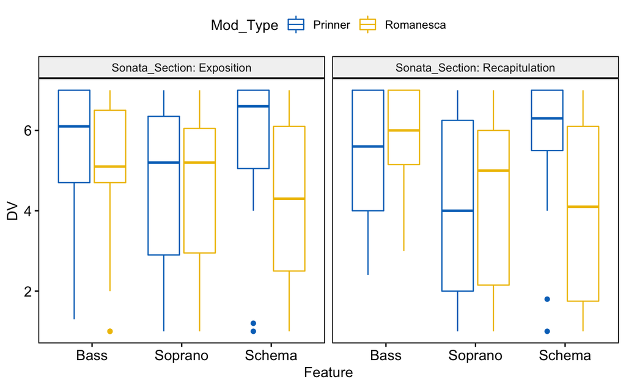

```r
bxp <- ggboxplot(
  df, x = "Feature", y = "DV",
  color = "Mod_Type", palette = "jco",
  facet.by = "Sonata_Section", short.panel.labs = FALSE
  )
print(bxp)
```

### Outliers

```r
df %>%
  group_by(Sonata_Section, Feature, Mod_Type, Expertise_Group) %>%
  identify_outliers(DV)
```

| Sonata_Section | Feature | Mod_Type | Expertise_Group | X | Random_IDs | DV | Education_Level | Years_Theory | Years_Skills | Schemata_Expertise | Excerpt_Familiarity | Excerpt_Analysis | Solfege_Hearing | Schema_Hearing | Perfect_Pitch. | Interpretation_App | Expertise_Group_solf | Sonata_Order | Expo_Order | Expo_Bass_Order | Expo_Sop_Order | Expo_Schema_Order | Recap_Order | Recap_Bass_Order | Recap_Sop_Order | Recap_Schema_Order | is.outlier | is.extreme |
| --- | --- | --- | --- | --- | --- | --- | --- | --- | --- | --- | --- | --- | --- | --- | --- | --- | --- | --- | --- | --- | --- | --- | --- | --- | --- | --- | --- | --- |
| Exposition | Bass | Prinner | Expert | 14 | 392 | 6.1 | Professor | 10 + years | 10 + years | I am an expert (analysis, playing, composition, etc.) | I have heard this before | No, not at all | 5.9 | 4.2 | Yes | I have no idea, I could just hear it! | Expert | 1 | 1 | 1 | 2 | 2 | 1 | 1 | 2 | 2 | TRUE | TRUE |
| Exposition | Bass | Prinner | Intermediate | 7 | 473 | 1.3 | Postdoctoral Researcher | 10 + years | 5-10 years | Somewhat familiar | I have heard this before | No, not at all | 6.0 | 5.1 | No | I spoke or sang scale degrees or solfege while listening | Intermediate | 2 | 5 | 1 | 1 | 1 | 3 | 2 | 1 | 2 | TRUE | FALSE |
| Exposition | Bass | Romanesca | Expert | 13 | 475 | 2.0 | Professor | 10 + years | 10 + years | I am an expert (analysis, playing, composition, etc.) | I have heard this before | No, not at all | 7.0 | 7.0 | Yes | Other (please specify) | Expert | 2 | 1 | 2 | 1 | 1 | 2 | 2 | 1 | 2 | TRUE | TRUE |
| Exposition | Bass | Romanesca | Expert | 18 | 540 | 7.0 | Professor | 5-10 years | 5-10 years | I am an expert (analysis, playing, composition, etc.) | I have heard this before | Yes, somewhat | 7.0 | 7.0 | No | I imagined scale degrees or solfege as I listened,I subvocalized (silent rehearsal, spoken or sung) scale degrees or solfege while listening,I played an instrument | Expert | 2 | 3 | 2 | 2 | 2 | 4 | 2 | 2 | 2 | TRUE | TRUE |
| Exposition | Schema | Prinner | Intermediate | 7 | 473 | 1.2 | Postdoctoral Researcher | 10 + years | 5-10 years | Somewhat familiar | I have heard this before | No, not at all | 6.0 | 5.1 | No | I spoke or sang scale degrees or solfege while listening | Intermediate | 2 | 5 | 1 | 1 | 1 | 3 | 2 | 1 | 2 | TRUE | TRUE |
| Exposition | Soprano | Romanesca | Intermediate | 3 | 862 | 2.4 | Graduate Student | 5-10 years | 5-10 years | Very familiar | This was the first time I have heard this | No, not at all | 5.5 | 4.9 | No | I imagined scale degrees or solfege as I listened,I subvocalized (silent rehearsal, spoken or sung) scale degrees or solfege while listening | Intermediate | 1 | 3 | 1 | 1 | 1 | 3 | 1 | 2 | 2 | TRUE | FALSE |
| Recapitulation | Bass | Prinner | Expert | 14 | 392 | 3.1 | Professor | 10 + years | 10 + years | I am an expert (analysis, playing, composition, etc.) | I have heard this before | No, not at all | 5.9 | 4.2 | Yes | I have no idea, I could just hear it! | Expert | 1 | 1 | 1 | 2 | 2 | 1 | 1 | 2 | 2 | TRUE | TRUE |
| Recapitulation | Schema | Prinner | Expert | 14 | 392 | 4.5 | Professor | 10 + years | 10 + years | I am an expert (analysis, playing, composition, etc.) | I have heard this before | No, not at all | 5.9 | 4.2 | Yes | I have no idea, I could just hear it! | Expert | 1 | 1 | 1 | 2 | 2 | 1 | 1 | 2 | 2 | TRUE | TRUE |
| Recapitulation | Schema | Prinner | Intermediate | 3 | 862 | 7.0 | Graduate Student | 5-10 years | 5-10 years | Very familiar | This was the first time I have heard this | No, not at all | 5.5 | 4.9 | No | I imagined scale degrees or solfege as I listened,I subvocalized (silent rehearsal, spoken or sung) scale degrees or solfege while listening | Intermediate | 1 | 3 | 1 | 1 | 1 | 3 | 1 | 2 | 2 | TRUE | FALSE |
| Recapitulation | Schema | Prinner | Intermediate | 7 | 473 | 1.8 | Postdoctoral Researcher | 10 + years | 5-10 years | Somewhat familiar | I have heard this before | No, not at all | 6.0 | 5.1 | No | I spoke or sang scale degrees or solfege while listening | Intermediate | 2 | 5 | 1 | 1 | 1 | 3 | 2 | 1 | 2 | TRUE | TRUE |

[output cut: 7 more lines]

### Assumption of Normality: Shapiro-Wilk Test

Secondly, we can use the Shapiro-Wilk test to examine whether the DV is normally distributed across levels of the IV.

Given that nearly all of the p-values are significant here, it is evident that there are sphericity violations in this dataset. As such, Greenhouse-Geisser corrections to p-values will be applied where applicable. Similarly, as the assumption of normality has been violated, all significant effects flagged in the ANOVA will be examined using the non-parametric Tukey HSD post-hoc test.

```r
df %>%
  group_by(Sonata_Section, Feature, Mod_Type) %>%
  shapiro_test(DV)
```

| Sonata_Section | Feature | Mod_Type | variable | statistic | p |
| --- | --- | --- | --- | --- | --- |
| Exposition | Bass | Prinner | DV | 0.8229830 | 0.0025145851 |
| Exposition | Bass | Romanesca | DV | 0.8407478 | 0.0047608703 |
| Exposition | Schema | Prinner | DV | 0.7378389 | 0.0001628304 |
| Exposition | Schema | Romanesca | DV | 0.9059972 | 0.0625343635 |
| Exposition | Soprano | Prinner | DV | 0.9019443 | 0.0527635463 |
| Exposition | Soprano | Romanesca | DV | 0.8939560 | 0.0378711665 |
| Recapitulation | Bass | Prinner | DV | 0.8544001 | 0.0079173745 |
| Recapitulation | Bass | Romanesca | DV | 0.8856240 | 0.0269355605 |
| Recapitulation | Schema | Prinner | DV | 0.7294434 | 0.0001274428 |
| Recapitulation | Schema | Romanesca | DV | 0.8903109 | 0.0326041380 |

[output cut: 2 more lines]

#### QQ Plot

We can also visualize these violations using QQplots.

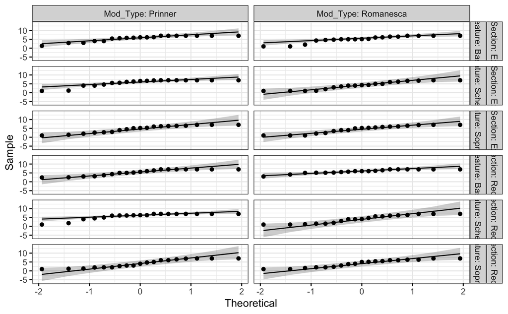

```r
ggqqplot(df, "DV", ggtheme = theme_bw()) +
  facet_grid(Sonata_Section ~ Feature ~ Mod_Type, labeller = "label_both")
```

### Assumption of Homogeneity of Variance: Levene Test

We can also test for homogeneity of variance using the Levene Test. This shows that there is homogeneity of variances (p > 0.05) for all factors except for the Exposition version of the Bassline Romanesca schema (p = 0.02)

```r
df %>%
  group_by(Sonata_Section, Feature, Mod_Type) %>%
  levene_test(DV ~ Expertise_Group)
```

| Sonata_Section | Feature | Mod_Type | df1 | df2 | statistic | p |
| --- | --- | --- | --- | --- | --- | --- |
| Exposition | Bass | Prinner | 2 | 16 | 2.4532182 | 0.11768463 |
| Exposition | Bass | Romanesca | 2 | 16 | 5.1145197 | 0.01917347 |
| Exposition | Schema | Prinner | 2 | 16 | 1.8072555 | 0.19603787 |
| Exposition | Schema | Romanesca | 2 | 16 | 0.1264135 | 0.88212177 |
| Exposition | Soprano | Prinner | 2 | 16 | 1.9042583 | 0.18119418 |
| Exposition | Soprano | Romanesca | 2 | 16 | 1.1970397 | 0.32774448 |
| Recapitulation | Bass | Prinner | 2 | 16 | 0.3855037 | 0.68625682 |
| Recapitulation | Bass | Romanesca | 2 | 16 | 1.7176154 | 0.21098046 |
| Recapitulation | Schema | Prinner | 2 | 16 | 2.3270790 | 0.12968803 |
| Recapitulation | Schema | Romanesca | 2 | 16 | 0.1237860 | 0.88440686 |

[output cut: 2 more lines]

We can also check the variance for Excerpt Familiarity, which has equal variance (p > 0.05).

```r
df %>%
  group_by(Sonata_Section, Feature, Mod_Type) %>%
  levene_test(DV ~ Excerpt_Familiarity)
```

| Sonata_Section | Feature | Mod_Type | df1 | df2 | statistic | p |
| --- | --- | --- | --- | --- | --- | --- |
| Exposition | Bass | Prinner | 2 | 16 | 0.3770193 | 0.6918370 |
| Exposition | Bass | Romanesca | 2 | 16 | 0.6911934 | 0.5153290 |
| Exposition | Schema | Prinner | 2 | 16 | 0.3162379 | 0.7333388 |
| Exposition | Schema | Romanesca | 2 | 16 | 0.9768721 | 0.3978502 |
| Exposition | Soprano | Prinner | 2 | 16 | 0.5904769 | 0.5656941 |
| Exposition | Soprano | Romanesca | 2 | 16 | 0.6497442 | 0.5354190 |
| Recapitulation | Bass | Prinner | 2 | 16 | 0.2879459 | 0.7536065 |
| Recapitulation | Bass | Romanesca | 2 | 16 | 2.1331400 | 0.1509272 |
| Recapitulation | Schema | Prinner | 2 | 16 | 0.2971816 | 0.7469218 |
| Recapitulation | Schema | Romanesca | 2 | 16 | 1.1421920 | 0.3438090 |

[output cut: 2 more lines]

Lastly, we can visualize the mean and standard deviations for the dependent variable, grouped by the levels of factors for reference following the ANOVA (see below).

```r
df %>%
  group_by(Sonata_Section, Feature, Mod_Type, Expertise_Group) %>%
  get_summary_stats(DV, type = "mean_sd")
```

| Sonata_Section | Feature | Mod_Type | Expertise_Group | variable | n | mean | sd |
| --- | --- | --- | --- | --- | --- | --- | --- |
| Exposition | Bass | Prinner | Expert | DV | 5 | 6.820 | 0.402 |
| Exposition | Bass | Prinner | Intermediate | DV | 10 | 5.030 | 1.742 |
| Exposition | Bass | Prinner | Novice | DV | 4 | 5.225 | 2.098 |
| Exposition | Bass | Romanesca | Expert | DV | 5 | 4.760 | 1.785 |
| Exposition | Bass | Romanesca | Intermediate | DV | 10 | 5.830 | 0.973 |
| Exposition | Bass | Romanesca | Novice | DV | 4 | 3.500 | 3.000 |
| Exposition | Schema | Prinner | Expert | DV | 5 | 7.000 | 0.000 |
| Exposition | Schema | Prinner | Intermediate | DV | 10 | 5.660 | 1.825 |
| Exposition | Schema | Prinner | Novice | DV | 4 | 3.975 | 2.210 |
| Exposition | Schema | Romanesca | Expert | DV | 5 | 2.700 | 1.591 |

[output cut: 26 more lines]

## 2. Four-Way Mixed ANOVA: 2* 3* 2 Factorial Design (Sonata Section, Feature, Modulation Type)

The survey design resulted in a four-way mixed ANOVA design, with 2* 3* 2 factorial design for the within-subject factors, and three levels of the between-subject factor. The within-subject factors included two levels of sonata section (exposition, recapitulation), three levels of attended feature (bass, soprano, schema) and two levels of modulation type (Prinner, Romanesca). The between-subject factor included the three levels of expertise group (expert, intermediate, novice).

```r
# Compute RM ANOVA for within and between subjects factors
res.aov.bet <- anova_test(
  data = df, dv = DV, wid = Random_IDs,
  within = c(Sonata_Section, Feature, Mod_Type), between=Expertise_Group
  )
get_anova_table(res.aov.bet, correction="GG")
```

```
ANOVA Table (type III tests)

                                            Effect  DFn   DFd      F        p p<.05      ges
1                                  Expertise_Group 2.00 16.00  6.966 0.007000     * 1.69e-01
2                                   Sonata_Section 1.00 16.00  0.004 0.950000       1.24e-05
3                                          Feature 1.94 31.11 11.884 0.000165     * 9.10e-02
4                                         Mod_Type 1.00 16.00  4.828 0.043000     * 7.00e-02
5                   Expertise_Group:Sonata_Section 2.00 16.00  0.858 0.443000       5.00e-03
6                          Expertise_Group:Feature 3.89 31.11  3.106 0.030000     * 5.00e-02
7                         Expertise_Group:Mod_Type 2.00 16.00  4.729 0.024000     * 1.28e-01
8                           Sonata_Section:Feature 1.67 26.68  6.687 0.006000     * 1.20e-02
9                          Sonata_Section:Mod_Type 1.00 16.00  3.931 0.065000       8.00e-03
10                                Feature:Mod_Type 1.95 31.27  5.444 0.010000     * 5.40e-02
11          Expertise_Group:Sonata_Section:Feature 3.34 26.68  1.266 0.307000       5.00e-03
12         Expertise_Group:Sonata_Section:Mod_Type 2.00 16.00  1.865 0.187000       8.00e-03
13                Expertise_Group:Feature:Mod_Type 3.91 31.27  0.645 0.631000       1.30e-02
14                 Sonata_Section:Feature:Mod_Type 1.55 24.87  1.045 0.350000       7.00e-03
15 Expertise_Group:Sonata_Section:Feature:Mod_Type 3.11 24.87  0.298 0.833000       4.00e-03
```

I will also output the greenhouse geisser corrections:

```r
res.aov.bet$`Sphericity Corrections`
```

| Effect | GGe | DF[GG] | p[GG] | p[GG]<.05 | HFe | DF[HF] | p[HF] | p[HF]<.05 |
| --- | --- | --- | --- | --- | --- | --- | --- | --- |
| Feature | 0.972 | 1.94, 31.11 | 0.000165 | * | 1.105 | 2.21, 35.35 | 0.000138 | * |
| Expertise_Group:Feature | 0.972 | 3.89, 31.11 | 0.030000 | * | 1.105 | 4.42, 35.35 | 0.029000 | * |
| Sonata_Section:Feature | 0.834 | 1.67, 26.68 | 0.006000 | * | 0.919 | 1.84, 29.42 | 0.005000 | * |
| Expertise_Group:Sonata_Section:Feature | 0.834 | 3.34, 26.68 | 0.307000 |  | 0.919 | 3.68, 29.42 | 0.305000 |  |
| Feature:Mod_Type | 0.977 | 1.95, 31.27 | 0.010000 | * | 1.111 | 2.22, 35.56 | 0.009000 | * |
| Expertise_Group:Feature:Mod_Type | 0.977 | 3.91, 31.27 | 0.631000 |  | 1.111 | 4.45, 35.56 | 0.635000 |  |
| Sonata_Section:Feature:Mod_Type | 0.777 | 1.55, 24.87 | 0.350000 |  | 0.845 | 1.69, 27.05 | 0.355000 |  |
| Expertise_Group:Sonata_Section:Feature:Mod_Type | 0.777 | 3.11, 24.87 | 0.833000 |  | 0.845 | 3.38, 27.05 | 0.848000 |  |

**Summary of Findings**

This analysis shows that there was a significant main effect of expertise (p = 0.007), feature (p < 0.001), and modulation type (p = 0.043), as well as significant two way interactions between expertise group and feature (p = 0.030), expertise group and modulation type (p = 0.024), sonata section and feature (p = 0.006), and feature and modulation type (p = 0.010).

I will now examine each of these effects using non-parametrics Tukey HSD tests to determine which pair-wise differences the significant effects stem from.

### Examining the Main Effects

Here, I examine the main effects using non-parametric tuckey hsd tests on each statistically significant main effect.

**Expertise**

```r
# Examine Main Effects

#Expertise

# tukey
df %>% tukey_hsd(DV ~ Expertise_Group, conf.level = 0.95)
```

|  | term | group1 | group2 | null.value | estimate | conf.low | conf.high | p.adj | p.adj.signif |
| --- | --- | --- | --- | --- | --- | --- | --- | --- | --- |
| 1 | Expertise_Group | Expert | Intermediate | 0 | 0.2233333 | -0.4772824 | 0.9239491 | 7.33e-01 | ns |
| 2 | Expertise_Group | Expert | Novice | 0 | -1.5729167 | -2.4309922 | -0.7148411 | 6.80e-05 | **** |
| 3 | Expertise_Group | Intermediate | Novice | 0 | -1.7962500 | -2.5530015 | -1.0394985 | 1.86e-07 | **** |

```r
NA
```

```r
df %>%
  group_by(Expertise_Group) %>%
  get_summary_stats(DV, type = "mean_sd")
```

| Expertise_Group | variable | n | mean | sd |
| --- | --- | --- | --- | --- |
| Expert | DV | 60 | 5.133 | 2.120 |
| Intermediate | DV | 120 | 5.357 | 1.603 |
| Novice | DV | 48 | 3.560 | 2.177 |

**Feature**

```r
# Feature

df %>% tukey_hsd(DV ~ Feature, conf.level = 0.95)
```

|  | term | group1 | group2 | null.value | estimate | conf.low | conf.high | p.adj | p.adj.signif |
| --- | --- | --- | --- | --- | --- | --- | --- | --- | --- |
| 1 | Feature | Bass | Schema | 0 | -0.5184211 | -1.268819 | 0.2319774 | 0.23500 | ns |
| 2 | Feature | Bass | Soprano | 0 | -1.0644737 | -1.814872 | -0.3140753 | 0.00275 | ** |
| 3 | Feature | Schema | Soprano | 0 | -0.5460526 | -1.296451 | 0.2043458 | 0.20100 | ns |

```r
NA
```

```r
df %>%
  group_by(Feature) %>%
  get_summary_stats(DV, type = "mean_sd")
```

| Feature | variable | n | mean | sd |
| --- | --- | --- | --- | --- |
| Bass | DV | 76 | 5.447 | 1.623 |
| Schema | DV | 76 | 4.929 | 2.137 |
| Soprano | DV | 76 | 4.383 | 2.081 |

The main effect of feature stems from the significant difference between bass (M = 5.44, sd = 1.62) and soprano (M = 4.38, sd = 2.08) features. This suggests that the soprano line was the most difficult to hear and attend to.

**Modulation Type**

```r
#Mod Type

df %>% tukey_hsd(DV ~ Mod_Type, conf.level = 0.95)
```

|  | term | group1 | group2 | null.value | estimate | conf.low | conf.high | p.adj | p.adj.signif |
| --- | --- | --- | --- | --- | --- | --- | --- | --- | --- |
| 1 | Mod_Type | Prinner | Romanesca | 0 | -0.5254386 | -1.044036 | -0.006841283 | 0.0471 | * |

```r
NA
```

```r
df %>%
  group_by(Mod_Type) %>%
  get_summary_stats(DV, type = "mean_sd")
```

| Mod_Type | variable | n | mean | sd |
| --- | --- | --- | --- | --- |
| Prinner | DV | 114 | 5.182 | 1.950 |
| Romanesca | DV | 114 | 4.657 | 2.024 |

The main effect of modulation type shows that the Prinner (M = 5.18, sd = 1.95) was easier to hear than the Romanesca (M = 4.65, sd = 2.02).

### Examining Two-Way Interactions

In this section, I examine the significant two way interactions between expertise group and feature (p = 0.030), expertise group and modulation type (p = 0.024), sonata section and feature (p = 0.006), and feature and modulation type (p = 0.010).

**Expertise and Feature**

```r
# Two Way Interactions

# Expertise Group by Feature

df %>%
  group_by(Expertise_Group) %>%
  tukey_hsd(DV ~ Feature, conf.level = 0.95)
```

|  | Expertise_Group | term | group1 | group2 | null.value | estimate | conf.low | conf.high | p.adj | p.adj.signif |
| --- | --- | --- | --- | --- | --- | --- | --- | --- | --- | --- |
| 1 | Expert | Feature | Bass | Schema | 0 | -1.10000 | -2.6968513 | 0.49685129 | 0.23000 | ns |
| 2 | Expert | Feature | Bass | Soprano | 0 | -0.94500 | -2.5418513 | 0.65185129 | 0.33500 | ns |
| 3 | Expert | Feature | Schema | Soprano | 0 | 0.15500 | -1.4418513 | 1.75185129 | 0.97000 | ns |
| 4 | Intermediate | Feature | Bass | Schema | 0 | 0.16750 | -0.6710387 | 1.00603865 | 0.88400 | ns |
| 5 | Intermediate | Feature | Bass | Soprano | 0 | -0.62000 | -1.4585387 | 0.21853865 | 0.18900 | ns |
| 6 | Intermediate | Feature | Schema | Soprano | 0 | -0.78750 | -1.6260387 | 0.05103865 | 0.07040 | ns |
| 7 | Novice | Feature | Bass | Schema | 0 | -1.50625 | -3.2115538 | 0.19905384 | 0.09300 | ns |
| 8 | Novice | Feature | Bass | Soprano | 0 | -2.32500 | -4.0303038 | -0.61969616 | 0.00522 | ** |
| 9 | Novice | Feature | Schema | Soprano | 0 | -0.81875 | -2.5240538 | 0.88655384 | 0.48100 | ns |

```r
NA
```

```r
df %>%
  group_by(Expertise_Group, Feature) %>%
  get_summary_stats(DV, type = "mean_sd")
```

| Feature | Expertise_Group | variable | n | mean | sd |
| --- | --- | --- | --- | --- | --- |
| Bass | Expert | DV | 20 | 5.815 | 1.600 |
| Schema | Expert | DV | 20 | 4.715 | 2.420 |
| Soprano | Expert | DV | 20 | 4.870 | 2.190 |
| Bass | Intermediate | DV | 40 | 5.508 | 1.395 |
| Schema | Intermediate | DV | 40 | 5.675 | 1.540 |
| Soprano | Intermediate | DV | 40 | 4.888 | 1.780 |
| Bass | Novice | DV | 16 | 4.838 | 2.070 |
| Schema | Novice | DV | 16 | 3.331 | 2.230 |
| Soprano | Novice | DV | 16 | 2.513 | 1.619 |

**Expertise and Modulation**

```r
# Expertise Group by Modulation Type

df %>%
  group_by(Expertise_Group) %>%
  tukey_hsd(DV ~ Mod_Type, conf.level = 0.95)
```

|  | Expertise_Group | term | group1 | group2 | null.value | estimate | conf.low | conf.high | p.adj | p.adj.signif |
| --- | --- | --- | --- | --- | --- | --- | --- | --- | --- | --- |
| 1 | Expert | Mod_Type | Prinner | Romanesca | 0 | -2.2200000 | -3.15851421 | -1.2814858 | 1.45e-05 | **** |
| 2 | Intermediate | Mod_Type | Prinner | Romanesca | 0 | 0.5566667 | -0.01638061 | 1.1297139 | 5.68e-02 | ns |
| 3 | Novice | Mod_Type | Prinner | Romanesca | 0 | -1.1125000 | -2.34776778 | 0.1227678 | 7.64e-02 | ns |

```r
df %>%
  group_by(Expertise_Group, Mod_Type) %>%
  get_summary_stats(DV, type = "mean_sd")
```

| Mod_Type | Expertise_Group | variable | n | mean | sd |
| --- | --- | --- | --- | --- | --- |
| Prinner | Expert | DV | 30 | 6.243 | 1.500 |
| Romanesca | Expert | DV | 30 | 4.023 | 2.085 |
| Prinner | Intermediate | DV | 60 | 5.078 | 1.811 |
| Romanesca | Intermediate | DV | 60 | 5.635 | 1.321 |
| Prinner | Novice | DV | 24 | 4.117 | 2.178 |
| Romanesca | Novice | DV | 24 | 3.004 | 2.072 |

**Sonata Section and Feature**

```r
# Sonata Section by Feature

df %>%
  group_by(Sonata_Section) %>%
  tukey_hsd(DV ~ Feature, conf.level = 0.95)
```

|  | Sonata_Section | term | group1 | group2 | null.value | estimate | conf.low | conf.high | p.adj | p.adj.signif |
| --- | --- | --- | --- | --- | --- | --- | --- | --- | --- | --- |
| 1 | Exposition | Feature | Bass | Schema | 0 | -0.3921053 | -1.479934 | 0.6957234 | 0.66900 | ns |
| 2 | Exposition | Feature | Bass | Soprano | 0 | -0.7052632 | -1.793092 | 0.3825655 | 0.27600 | ns |
| 3 | Exposition | Feature | Schema | Soprano | 0 | -0.3131579 | -1.400987 | 0.7746707 | 0.77300 | ns |
| 4 | Recapitulation | Feature | Bass | Schema | 0 | -0.6447368 | -1.701783 | 0.4123094 | 0.32000 | ns |
| 5 | Recapitulation | Feature | Bass | Soprano | 0 | -1.4236842 | -2.480730 | -0.3666380 | 0.00507 | ** |
| 6 | Recapitulation | Feature | Schema | Soprano | 0 | -0.7789474 | -1.835994 | 0.2780989 | 0.19100 | ns |

```r
NA
```

```r
df %>%
  group_by(Sonata_Section, Feature) %>%
  get_summary_stats(DV, type = "mean_sd")
```

| Sonata_Section | Feature | variable | n | mean | sd |
| --- | --- | --- | --- | --- | --- |
| Exposition | Bass | DV | 38 | 5.300 | 1.793 |
| Exposition | Schema | DV | 38 | 4.908 | 2.148 |
| Exposition | Soprano | DV | 38 | 4.595 | 2.031 |
| Recapitulation | Bass | DV | 38 | 5.595 | 1.443 |
| Recapitulation | Schema | DV | 38 | 4.950 | 2.154 |
| Recapitulation | Soprano | DV | 38 | 4.171 | 2.137 |

The Tukey HSD test on the interaction between sonata section and feature revealed that only for the recapitulation did soprano (M = 4.17, sd = 2.13) and bass (M = 5.59, sd = 1.44) significantly differ.

**Feature and Modulation Type**

```r
# Feature by Modulation Type

df %>%
  group_by(Feature) %>%
  tukey_hsd(DV ~ Mod_Type, conf.level = 0.95)
```

|  | Feature | term | group1 | group2 | null.value | estimate | conf.low | conf.high | p.adj | p.adj.signif |
| --- | --- | --- | --- | --- | --- | --- | --- | --- | --- | --- |
| 1 | Bass | Mod_Type | Prinner | Romanesca | 0 | 0.02631579 | -0.7206944 | 0.7733260 | 0.94400 | ns |
| 2 | Schema | Mod_Type | Prinner | Romanesca | 0 | -1.55263158 | -2.4677279 | -0.6375353 | 0.00116 | ** |
| 3 | Soprano | Mod_Type | Prinner | Romanesca | 0 | -0.05000000 | -1.0078044 | 0.9078044 | 0.91700 | ns |

```r
NA
```

```r
df %>%
  group_by(Feature, Mod_Type) %>%
  get_summary_stats(DV, type = "mean_sd")
```

| Feature | Mod_Type | variable | n | mean | sd |
| --- | --- | --- | --- | --- | --- |
| Bass | Prinner | DV | 38 | 5.434 | 1.684 |
| Bass | Romanesca | DV | 38 | 5.461 | 1.583 |
| Schema | Prinner | DV | 38 | 5.705 | 1.816 |
| Schema | Romanesca | DV | 38 | 4.153 | 2.172 |
| Soprano | Prinner | DV | 38 | 4.408 | 2.124 |
| Soprano | Romanesca | DV | 38 | 4.358 | 2.066 |

The post hoc Tukey HSD test revealed that for the schema attending condition only did Prinner (M = 5.70, sd = 1.81) and Romanesca (M = 4.15, sd = 2.17) interpretations differ.

### Examining Effect of Stimuli Presentation Order

In order to examine in the order in which stimuli was presented had an effect on interpretation formation, a second ANOVA including Sonata Order as a between-subjects factor, in addition to expertise group, was completed. This showed however that there was no effect of order of presentation of sonata section on the DV.

```r
res.aov.order <- anova_test(
  data = df, dv = DV, wid = Random_IDs,
  within = c(Sonata_Section, Feature, Mod_Type), between=c(Expertise_Group, Sonata_Order)
  )
get_anova_table(res.aov.order)
```

```
ANOVA Table (type III tests)

                                                         Effect DFn DFd     F     p p<.05   ges
1                                               Expertise_Group   2  13 5.942 0.015     * 0.188
2                                                  Sonata_Order   1  13 0.193 0.668       0.004
3                                                Sonata_Section   1  13 0.796 0.388       0.002
4                                                       Feature   2  26 8.478 0.001     * 0.082
5                                                      Mod_Type   1  13 2.493 0.138       0.043
6                                  Expertise_Group:Sonata_Order   2  13 0.392 0.683       0.015
7                                Expertise_Group:Sonata_Section   2  13 2.792 0.098       0.017
8                                   Sonata_Order:Sonata_Section   1  13 0.969 0.343       0.003
9                                       Expertise_Group:Feature   4  26 2.397 0.076       0.048
10                                         Sonata_Order:Feature   2  26 1.183 0.322       0.012
11                                     Expertise_Group:Mod_Type   2  13 2.150 0.156       0.072
12                                        Sonata_Order:Mod_Type   1  13 0.354 0.562       0.006
```

[output cut: 19 more lines]

# Statistical Analysis: Dependent Variable 2 (Ease of Change Ratings)

In the second section of this analysis, I perform the same statistical tests on the second dependent variable, ease of change ratings. In the first section, I perform cursory EDA, including examining the assumptions of normality and variance prior to performing the ANOVA (again, for a full EDA, please see the corresponding EDA jupyter notebook). I then perform the mixed factorial ANOVA examining the effect of two within-subject factors (sonata section, attended feature) and one between-subject factor (expertise) on ease of change ratings (DV2).

```r
# loading the data
df2 <- readfile <- read.csv("data/amb_DV2_fin.csv")

# view the data
View(df2)

# Examine the data contents and data types
str(df2)
```

```
'data.frame':   114 obs. of  26 variables:
 $ X                   : int  0 1 2 3 4 6 7 8 9 10 ...
 $ Random_IDs          : int  913 834 719 862 686 998 473 895 326 381 ...
 $ Sonata_Section      : chr  "Exposition" "Exposition" "Exposition" "Exposition" ...
 $ Feature             : chr  "Bass" "Bass" "Bass" "Bass" ...
 $ DV2                 : num  3 4.7 6 6 6.3 1 1.2 1 5.6 1 ...
 $ Education_Level     : chr  "Professor" "Graduate Student" "Graduate Student" "Graduate Student" ...
 $ Years_Theory        : chr  "10 + years" "5-10 years" "1-2 years" "5-10 years" ...
 $ Years_Skills        : chr  "10 + years" "5-10 years" "3-5 years" "5-10 years" ...
 $ Schemata_Expertise  : chr  "Completely unfamiliar" "Familiar" "Somewhat familiar" "Very familiar" ...
 $ Excerpt_Familiarity : chr  "I have heard this before" "This was the first time I have heard this" "I have heard this before" "This was the first time I have heard this" ...
 $ Excerpt_Analysis    : chr  "No, not at all" "No, not at all" "No, not at all" "No, not at all" ...
 $ Solfege_Hearing     : num  7 6.2 5.3 5.5 7 4 6 4 6.1 7 ...
 $ Schema_Hearing      : num  1 5.7 4.5 4.9 7 2 5.1 1 4 1 ...
 $ Perfect_Pitch.      : chr  "No" "No" "No" "No" ...
 $ Interpretation_App  : chr  "I have no idea, I could just hear it!,I imagined scale degrees or solfege as I listened,I imagined or sung/spok"| __truncated__ "I imagined scale degrees or solfege as I listened" "I imagined scale degrees or solfege as I listened,I sang or spoke (without scale degrees…
 $ Expertise_Group     : chr  "Novice" "Intermediate" "Intermediate" "Intermediate" ...
 $ Expertise_Group_solf: chr  "Expert" "Intermediate" "Intermediate" "Intermediate" ...
 $ Sonata_Order        : int  2 1 2 1 2 1 2 2 2 1 ...
 $ Expo_Order          : int  5 3 3 3 1 6 5 6 1 5 ...
 $ Expo_Bass_Order     : int  1 2 2 1 2 1 1 2 1 1 ...
 $ Expo_Sop_Order      : int  1 2 2 1 1 2 1 1 1 2 ...
 $ Expo_Schema_Order   : int  2 2 1 1 1 2 1 1 1 2 ...
 $ Recap_Order         : int  3 1 6 3 4 3 3 2 3 6 ...
 $ Recap_Bass_Order    : int  1 2 2 1 1 1 2 2 2 1 ...
 $ Recap_Sop_Order     : int  1 2 1 2 1 1 1 2 1 1 ...
 $ Recap_Schema_Order  : int  2 1 1 2 1 1 2 2 1 2 ...
```

## 1. Cursory EDA

Here I examine outliers and assumptions of normality and variance prior to statistical analysis.

```r
df2 %>%
  group_by(Feature) %>%
  get_summary_stats(DV2, type = "mean_sd")
```

| Feature | variable | n | mean | sd |
| --- | --- | --- | --- | --- |
| Bass | DV2 | 38 | 4.145 | 1.965 |
| Schema | DV2 | 38 | 3.742 | 2.072 |
| Soprano | DV2 | 38 | 3.145 | 2.019 |

## Outliers

The outlier analysis shows that the novice and intermediate groups have some outliers across most attended features. These came primarily from two participants (473 and 913), who provided very low ratings (intermediate group) and relatively high ratings (novice group) compared to their peers. I will however be keeping all datapoints because of the small sample size in the current dataset.

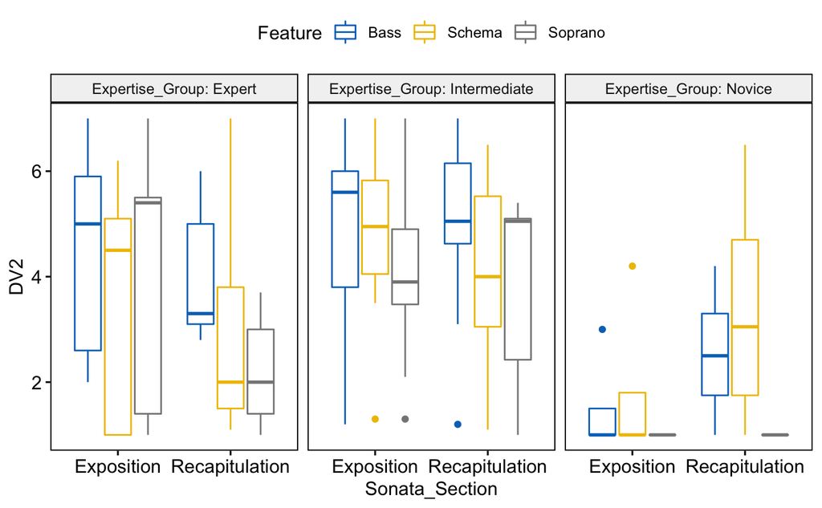

```r
bxp2 <- ggboxplot(
  df2, x = "Sonata_Section", y = "DV2",
  color = "Feature", palette = "jco",
  facet.by = "Expertise_Group", short.panel.labs = FALSE
  )
print(bxp2)
```

```r
df2 %>%
  group_by(Sonata_Section, Feature, Expertise_Group) %>%
  identify_outliers(DV2)
```

| Sonata_Section | Feature | Expertise_Group | X | Random_IDs | DV2 | Education_Level | Years_Theory | Years_Skills | Schemata_Expertise | Excerpt_Familiarity | Excerpt_Analysis | Solfege_Hearing | Schema_Hearing | Perfect_Pitch. | Interpretation_App | Expertise_Group_solf | Sonata_Order | Expo_Order | Expo_Bass_Order | Expo_Sop_Order | Expo_Schema_Order | Recap_Order | Recap_Bass_Order | Recap_Sop_Order | Recap_Schema_Order | is.outlier | is.extreme |
| --- | --- | --- | --- | --- | --- | --- | --- | --- | --- | --- | --- | --- | --- | --- | --- | --- | --- | --- | --- | --- | --- | --- | --- | --- | --- | --- | --- |
| Exposition | Bass | Novice | 0 | 913 | 3.0 | Professor | 10 + years | 10 + years | Completely unfamiliar | I have heard this before | No, not at all | 7 | 1.0 | No | I have no idea, I could just hear it!,I imagined scale degrees or solfege as I listened,I imagined or sung/spoke the interpretation between listenings | Expert | 2 | 5 | 1 | 1 | 2 | 3 | 1 | 1 | 2 | TRUE | FALSE |
| Exposition | Schema | Intermediate | 7 | 473 | 1.3 | Postdoctoral Researcher | 10 + years | 5-10 years | Somewhat familiar | I have heard this before | No, not at all | 6 | 5.1 | No | I spoke or sang scale degrees or solfege while listening | Intermediate | 2 | 5 | 1 | 1 | 1 | 3 | 2 | 1 | 2 | TRUE | FALSE |
| Exposition | Schema | Novice | 0 | 913 | 4.2 | Professor | 10 + years | 10 + years | Completely unfamiliar | I have heard this before | No, not at all | 7 | 1.0 | No | I have no idea, I could just hear it!,I imagined scale degrees or solfege as I listened,I imagined or sung/spoke the interpretation between listenings | Expert | 2 | 5 | 1 | 1 | 2 | 3 | 1 | 1 | 2 | TRUE | FALSE |
| Exposition | Soprano | Intermediate | 7 | 473 | 1.3 | Postdoctoral Researcher | 10 + years | 5-10 years | Somewhat familiar | I have heard this before | No, not at all | 6 | 5.1 | No | I spoke or sang scale degrees or solfege while listening | Intermediate | 2 | 5 | 1 | 1 | 1 | 3 | 2 | 1 | 2 | TRUE | FALSE |
| Recapitulation | Bass | Intermediate | 7 | 473 | 1.2 | Postdoctoral Researcher | 10 + years | 5-10 years | Somewhat familiar | I have heard this before | No, not at all | 6 | 5.1 | No | I spoke or sang scale degrees or solfege while listening | Intermediate | 2 | 5 | 1 | 1 | 1 | 3 | 2 | 1 | 2 | TRUE | FALSE |

### Assumption of Normality: Shapiro-Wilk Test

```r
df2 %>%
  group_by(Sonata_Section, Feature) %>%
  shapiro_test(DV2)
```

| Sonata_Section | Feature | variable | statistic | p |
| --- | --- | --- | --- | --- |
| Exposition | Bass | DV2 | 0.8945824 | 0.038862353 |
| Exposition | Schema | DV2 | 0.8741032 | 0.016975843 |
| Exposition | Soprano | DV2 | 0.8824087 | 0.023652468 |
| Recapitulation | Bass | DV2 | 0.9579195 | 0.532117070 |
| Recapitulation | Schema | DV2 | 0.9208524 | 0.117351203 |
| Recapitulation | Soprano | DV2 | 0.8009539 | 0.001179928 |

### GG Plot

The GG plot also shows that the DV2 is much less normally distributed than DV1. Caution must be taken when drawing any conclusions prior to application of the Tucky HSD tests.

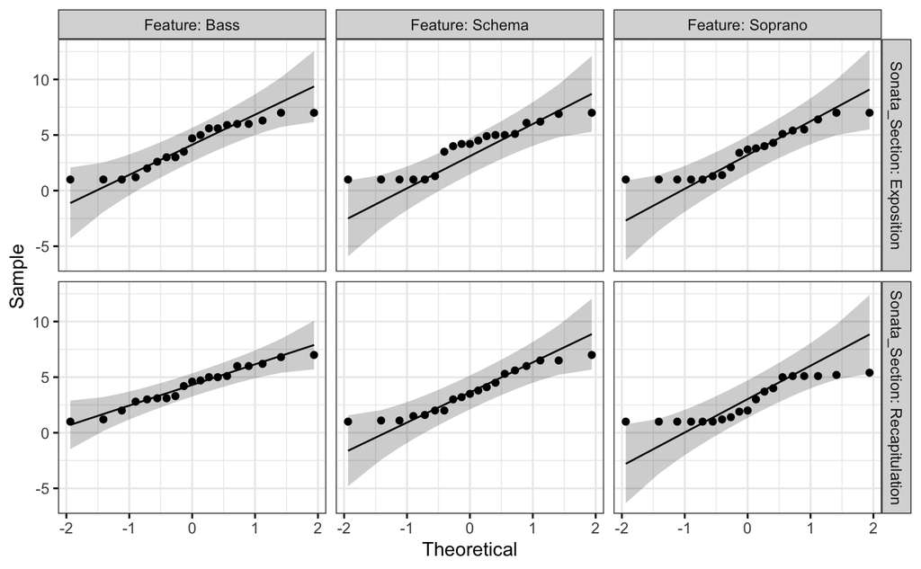

```r
ggqqplot(df2, "DV2", ggtheme = theme_bw()) +
  facet_grid(Sonata_Section ~ Feature , labeller = "label_both")
```

### Assumption of Homogeneity of Variance: Levene Test

Lastly, I test for homogeneity of variance using the Levene test. This shows that there is equal variance across levels of the DV.

```r
df2 %>%
  group_by(Sonata_Section, Feature) %>%
  levene_test(DV2 ~ Expertise_Group)
```

| Sonata_Section | Feature | df1 | df2 | statistic | p |
| --- | --- | --- | --- | --- | --- |
| Exposition | Bass | 2 | 16 | 0.9414962 | 0.4106183 |
| Exposition | Schema | 2 | 16 | 0.7130095 | 0.5050966 |
| Exposition | Soprano | 2 | 16 | 2.4655127 | 0.1165832 |
| Recapitulation | Bass | 2 | 16 | 0.0948804 | 0.9099895 |
| Recapitulation | Schema | 2 | 16 | 0.1057437 | 0.9002787 |
| Recapitulation | Soprano | 2 | 16 | 1.3613317 | 0.2844584 |

## 2. Three-Way Mixed ANOVA: 2*3 Factorial Design (Sonata Section, Feature)

A mixed ANOVA was performed in order to examine the effects of two within subject factors (sonata section and feature) as well as one between subject factor (expertise group) on DV2, ease of change rating.

```r
res.aov.bet2 <- anova_test(
  data = df2, dv = DV2, wid = Random_IDs,
  within = c(Sonata_Section, Feature), between=Expertise_Group
)
get_anova_table(res.aov.bet2, correction="GG")
```

```
ANOVA Table (type III tests)

                                  Effect  DFn   DFd     F     p p<.05   ges
1                        Expertise_Group 2.00 16.00 4.781 0.024     * 0.268
2                         Sonata_Section 1.00 16.00 0.157 0.697       0.001
3                                Feature 1.56 24.93 4.921 0.022     * 0.055
4         Expertise_Group:Sonata_Section 2.00 16.00 2.777 0.092       0.035
5                Expertise_Group:Feature 3.12 24.93 0.976 0.422       0.023
6                 Sonata_Section:Feature 1.68 26.80 2.208 0.136       0.013
7 Expertise_Group:Sonata_Section:Feature 3.35 26.80 1.371 0.272       0.016
```

```r
res.aov.bet2$'Sphericity Corrections'
```

| Effect | GGe | DF[GG] | p[GG] | p[GG]<.05 | HFe | DF[HF] | p[HF] | p[HF]<.05 |
| --- | --- | --- | --- | --- | --- | --- | --- | --- |
| Feature | 0.779 | 1.56, 24.93 | 0.022 | * | 0.848 | 1.7, 27.14 | 0.019 | * |
| Expertise_Group:Feature | 0.779 | 3.12, 24.93 | 0.422 |  | 0.848 | 3.39, 27.14 | 0.427 |  |
| Sonata_Section:Feature | 0.838 | 1.68, 26.8 | 0.136 |  | 0.924 | 1.85, 29.58 | 0.131 |  |
| Expertise_Group:Sonata_Section:Feature | 0.838 | 3.35, 26.8 | 0.272 |  | 0.924 | 3.7, 29.58 | 0.269 |  |

The analysis revealed that there were only main effets of expertise group (p = 0.024) and feature (p = 0.022).

### Examining the Main Effects

Here I will use Tukey HSD tests to examine the main effects.

**Expertise**

```r
df2 %>%
  tukey_hsd(DV2 ~ Expertise_Group, conf.level = 0.95)
```

|  | term | group1 | group2 | null.value | estimate | conf.low | conf.high | p.adj | p.adj.signif |
| --- | --- | --- | --- | --- | --- | --- | --- | --- | --- |
| 1 | Expertise_Group | Expert | Intermediate | 0 | 0.8716667 | -0.08201455 | 1.8253479 | 8.07e-02 | ns |
| 2 | Expertise_Group | Expert | Novice | 0 | -1.7016667 | -2.86968285 | -0.5336505 | 2.19e-03 | ** |
| 3 | Expertise_Group | Intermediate | Novice | 0 | -2.5733333 | -3.60342678 | -1.5432399 | 1.02e-07 | **** |

```r
df2 %>%
  group_by(Expertise_Group) %>%
  get_summary_stats(DV2, type = "mean_sd")
```

| Expertise_Group | variable | n | mean | sd |
| --- | --- | --- | --- | --- |
| Expert | DV2 | 30 | 3.577 | 2.066 |
| Intermediate | DV2 | 60 | 4.448 | 1.757 |
| Novice | DV2 | 24 | 1.875 | 1.503 |

**Feature**

```r
df2 %>%
  tukey_hsd(DV2 ~ Feature, conf.level = 0.95)
```

|  | term | group1 | group2 | null.value | estimate | conf.low | conf.high | p.adj | p.adj.signif |
| --- | --- | --- | --- | --- | --- | --- | --- | --- | --- |
| 1 | Feature | Bass | Schema | 0 | -0.4026316 | -1.502975 | 0.6977117 | 0.6610 | ns |
| 2 | Feature | Bass | Soprano | 0 | -1.0000000 | -2.100343 | 0.1003433 | 0.0829 | ns |
| 3 | Feature | Schema | Soprano | 0 | -0.5973684 | -1.697712 | 0.5029748 | 0.4040 | ns |

```r
NA
```

```r
df2 %>%
  group_by(Feature) %>%
  get_summary_stats(DV2, type = "mean_sd")
```

| Feature | variable | n | mean | sd |
| --- | --- | --- | --- | --- |
| Bass | DV2 | 38 | 4.145 | 1.965 |
| Schema | DV2 | 38 | 3.742 | 2.072 |
| Soprano | DV2 | 38 | 3.145 | 2.019 |

While the ANOVA revealed a significant effect of feature for DV2, the more conservative nonparametric Tukey HSD test showed that all pair-wise differences of feature were nonsignificant.

# Results Summary and Discussion

Here, I will contextualize the findings in light of the original hypotheses.

## Null Hypothesis

Firstly, we can safely reject the null hypothesis:

**H0:** This excerpt is not amenable to multiple interpretations, for either scale degree interpretations or Galant schemata.

Both excerpts were amenable to multiple interpretations for both scale degree lines and Galant schemata.

## First Hypothesis

Regarding the first hypothesis:

**H1a:** This excerpt is amenable to multiple interpretations in terms of schemata; however, one interpretation (Prinner) may be easier to hear than the other (Romanesca).

and

**H1b:** Furthermore, the availability of and ease of change between interpretations may differ between the expositional and recapitulatory versions of the excerpt (with the Romanesca more available in the recapitulation).

Hypothesis 1a was confirmed as the Prinner schema was rated as easier to hear than the Romanesca. However, the significant interaction between expertise and modulation type showed that this effect stemmed from rigidity in interpreation in the expert group only. The intermediate group was more easily able to alternate interpretations, showing that for this group, the excerpt was in fact more bistable. Hypothesis 1b was rejected as there was no interaction between modulation type and sonata section, indicating that the order of presentation did not affect interpretation formation.

## Second Hypothesis

For the second hypothesis:

**H2:** Participants should be able to more easily form and alternate between scale degree interpretations for a single voice (soprano, bass) than for Galant schemata (which are dependent on the presence of multiple, co-occurring features).

## Third Hypothesis

And lastly,

**H3:** The ability to form and alternate Galant schemata interpretations may be dependent on moderate familiarity, but not a high-level expertise with Galant schemata (Expertise categories = Novice, Intermediate, Expert). Expertise should therefore be related to increased rigidity of interpretation (Ease of Change on a scale from 1 to 7, low to high), particularly for Schema interpretations, as such categories are overlearned and more likely to be automatically active during listening.

# Conclusions